# Principais métricas por grupo de anúncio:

```python
adsetsum= qd_df.groupby('Nome do conjunto de anúncios').sum()
#series manipulation from adsetsum
adsetsum['Valor gasto (BRL)'] = adsetsum['Valor gasto (BRL)'].round(2).map(
    'R${}'.format)
#-----
adset1= adsetsum[['Valor gasto (BRL)','Alcance', 'Resultados',
    'Ativações de aplicativos','Ativações do aplicativo únicas']]

adsetmean = qd_df.groupby('Nome do conjunto de anúncios').mean()
#series manipulation from adsetmean
adsetmean['Custo por resultado'] = adsetmean['Custo por resultado'].round(2).map(
    'R${}'.format)
adsetmean['Custo por ativação de aplicativo'] = adsetmean['Custo por ativação de aplicativo'].round(2).map(
    'R${}'.format)
adsetmean['Custo por ativação do aplicativo única'] = adsetmean['Custo por ativação do aplicativo única'].round(2).map(
    'R${}'.format)
#-----

adset2= adsetmean[['Custo por resultado','Custo por ativação de aplicativo',
   'Custo por ativação do aplicativo única']]

#concat------
adset_final= pd.concat([adset1,adset2],axis=1, join='inner')

adset_final[[
    'Valor gasto (BRL)', 'Alcance', 'Resultados', 'Custo por resultado',
    'Ativações de aplicativos', 'Custo por ativação de aplicativo',
    'Ativações do aplicativo únicas', 'Custo por ativação do aplicativo única'
]].sort_values(by = 'Ativações do aplicativo únicas', ascending = False)
```

| Nome do conjunto de anúncios | Valor gasto (BRL) | Alcance | Resultados | Custo por resultado | Ativações de aplicativos | Custo por ativação de aplicativo | Ativações do aplicativo únicas | Custo por ativação do aplicativo única |
| --- | --- | --- | --- | --- | --- | --- | --- | --- |
| QD_Produtos | R$2000.09 | 384833 | 1942 | R$0.64 | 146819 | R$0.01 | 59227 | R$0.04 |
| QD_Vantagens | R$2000.11 | 366466 | 1984 | R$0.63 | 132276 | R$0.01 | 54167 | R$0.04 |

# Principais resultados:

A campanha de tráfego no mês de novembro, com menos investimento e com menos tempo de veiculação, obteve um resultado em termos de custo por ativação e ativação superior ao mês anterior. Com base em análises podemos indicar que a criação de uma campanha agrupando todas a regiões e também a seleção de público mais aberta ao uso do app, foram fundamentais para os resultados. Vale ressaltar também que os dois grupos de anúncio obtveram resultados próximos, por isso rodaram os dois durante todo o período (**QD_Produtos** com **146819** ativações e **QD_Vantagens** com **132276** ativações)

# Resultados por Região

### As 5 principais por quantidade de cliques são:

```python
qd_region['Cliques (todos)'].sum().sort_values(ascending = False).head(5)
```

```
Região
Bahia                1834
Pernambuco           1116
Sergipe               753
Paraíba               625
São Paulo (state)     407
Name: Cliques (todos), dtype: int64
```

```python
 qd_df[(qd_df['Custo por resultado'] > 0)].groupby('Região').mean().round(
    2).head(5)['Custo por resultado'].sort_values()
```

```
Região
Maranhão    0.30
Goiás       0.61
Bahia       1.10
Alagoas     1.20
Ceará       1.31
Name: Custo por resultado, dtype: float64
```

### As 5 principais com maior número de ativações:

```python
qd_region['Ativações de aplicativos'].sum().sort_values(ascending= False).head(5)
```

```
Região
Bahia         86147
Sergipe       78908
Paraíba       43691
Pernambuco    35270
Alagoas       12353
Name: Ativações de aplicativos, dtype: int64
```

## Total de cliques em todas as regiões

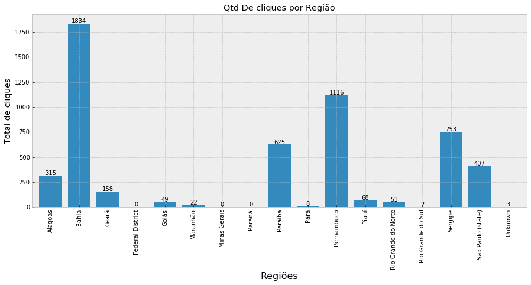

```python
plot_style = plt.style.use(['bmh'])
fig = plt.figure(figsize=(15,6))

set_graph_region= qd_df.groupby('Região')['Cliques (todos)'].sum().plot(kind = 'bar', width=0.8)
plt.title('Qtd De cliques por Região')

for i in set_graph_region.patches:
    plt.annotate(i.get_height().round(2),
            (i.get_x() + i.get_width()/ 2, i.get_height()),
            ha='center', va = 'baseline',
            fontsize = 10, xytext = (0,1), textcoords = 'offset points')
set_graph_region.set_xlabel( "Regiões", fontsize = 16)
set_graph_region.set_ylabel('Total de cliques', fontsize = 14)
```

## Total de Ativações em todas as regiões

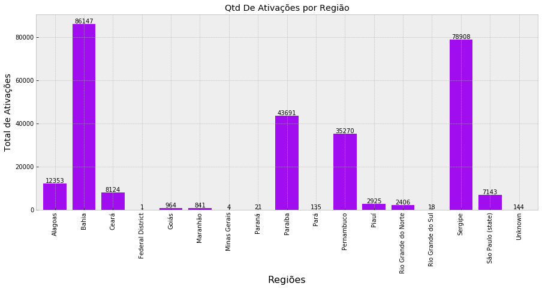

```python
plot_style = plt.style.use(['bmh'])
fig = plt.figure(figsize=(15, 6))

set_graph_region = qd_df.groupby(
    'Região')['Ativações de aplicativos'].sum().plot(kind='bar',
                                                     width=0.8,
                                                     color='#A00EF0')
plt.title('Qtd De Ativações por Região')

for i in set_graph_region.patches:
    plt.annotate(i.get_height().round(2),
                 (i.get_x() + i.get_width() / 2, i.get_height()),
                 ha='center',
                 va='baseline',
                 fontsize=10,
                 xytext=(0, 1),
                 textcoords='offset points')

set_graph_region.set_xlabel("Regiões", fontsize=16)
set_graph_region.set_ylabel('Total de Ativações', fontsize=14)
```

# Dados gerais:

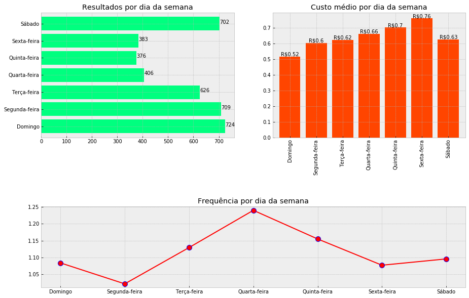

```python
plt.style.use(['bmh'])
fig = plt.figure(figsize=(15,10))
gs = gridspec.GridSpec(3,2)
order_day = [ 'Domingo','Segunda-feira', 'Terça-feira', 'Quarta-feira', 'Quinta-feira', 'Sexta-feira', 'Sábado']
set_graph = qd_df
ax1 = fig.add_subplot(221)
ax1_graph = set_graph.groupby('Weekday') ['Resultados'].sum().loc[order_day].plot(kind='barh',
        width = 0.8, color = 'springgreen',
        title = 'Resultados por dia da semana')
for i in ax1_graph.patches:
  plt.annotate(i.get_width(),
            ( i.get_width()+0.5, i.get_y()+i.get_height() /2),
            fontsize = 10
                 )
ax1_graph.set_ylabel('')
#_______

ax2 = fig.add_subplot(222)
ax2_graph= set_graph.groupby('Weekday') ['Custo por resultado'].mean().loc[order_day].plot(kind = 'bar',
       width = 0.8, color = 'orangered', title = 'Custo médio por dia da semana')
for i in ax2_graph.patches:
  plt.annotate('R$'+str(i.get_height().round(2)),
            (i.get_x() + i.get_width()/ 2, i.get_height()),
            ha='center', va = 'baseline',
            fontsize = 10, xytext = (0,1), textcoords = 'offset points' )
ax2_graph.set_xlabel('')
#______

ax3 = fig.add_subplot(gs[-1,:])
ax3_graph = set_graph.groupby('Weekday') ['Frequência'].mean().loc[order_day].plot( marker='o', ms=10,  mec='b',color = 'red',
                    title = 'Frequência por dia da semana')
ax3_graph.set_xlabel('')
```

No gráfico acima, observe que o melhor dia não foi o que houve a maior frequência de alcance, ou seja, não necessáriamente os anúncios do Quero delivery precisam aparecer mais que 2 vezes para obter bons resultados de engajamento com a campanha.

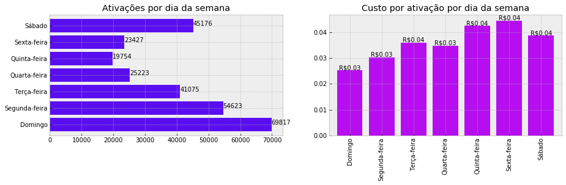

```python
plt.style.use(['bmh'])
fig = plt.figure(figsize=(15,8))
gs = gridspec.GridSpec(3,2)
order_day = [ 'Domingo','Segunda-feira', 'Terça-feira', 'Quarta-feira', 'Quinta-feira', 'Sexta-feira', 'Sábado']
set_graph = qd_df
ax1 = fig.add_subplot(221)
ax1_graph = set_graph.groupby('Weekday') ['Ativações de aplicativos'].sum().loc[order_day].plot(kind='barh',
        width = 0.8, color = '#5A0EF0',
        title = 'Ativações por dia da semana')
for i in ax1_graph.patches:
  plt.annotate(i.get_width(),
            ( i.get_width()+0.5, i.get_y()+i.get_height() /2),
            fontsize = 10
                 )
ax1_graph.set_ylabel('')
#_______

ax2 = fig.add_subplot(222)
ax2_graph= set_graph.groupby('Weekday') ['Custo por ativação do aplicativo única'].mean().loc[order_day].plot(kind = 'bar',
       width = 0.8, color = '#B60EF0', title = 'Custo por ativação por dia da semana')
for i in ax2_graph.patches:
  plt.annotate('R$'+str(i.get_height().round(2)),
            (i.get_x() + i.get_width()/ 2, i.get_height()),
            ha='center', va = 'baseline',
            fontsize = 10, xytext = (0,1), textcoords = 'offset points' )
ax2_graph.set_xlabel('')
```

Por fim, no gráfico acima vemos que existe uma queda considerável no uso do app (em relação à ativação) entre quarta e sexta, podendo ser uma boa oportunidade de criar promoções específicas para esses dias.

## Quaisquer dúvidas estou a dispoção!

Anthony Cavalcante

**Data Analyst | Digital Traffic Manager**